# Import Packages

```python
import pandas as pd
import numpy as np
import matplotlib.pyplot as plt
%matplotlib inline
from scipy import stats
import re
import seaborn as sns
sns.set(style="darkgrid")

pd.options.mode.chained_assignment = None #set it to None to remove SettingWithCopyWarning
pd.options.display.float_format = '{:.4f}'.format #set it to convert scientific noations such as 4.225108e+11 to 422510842796.00
pd.set_option('display.max_columns', 100) # to display all the columns

np.set_printoptions(suppress=True,formatter={'float_kind':'{:f}'.format})

import os

import warnings
warnings.filterwarnings('ignore') # if there are any warning due to version mismatch, it will be ignored
```

# Data Loading and Understanding

```python
df = pd.read_csv('loan.csv')
df.head()
```

|  | id | member_id | loan_amnt | funded_amnt | funded_amnt_inv | term | int_rate | installment | grade | sub_grade | emp_title | emp_length | home_ownership | annual_inc | verification_status | issue_d | loan_status | pymnt_plan | url | desc | purpose | title | zip_code | addr_state | dti | delinq_2yrs | earliest_cr_line | inq_last_6mths | mths_since_last_delinq | … |
| --- | --- | --- | --- | --- | --- | --- | --- | --- | --- | --- | --- | --- | --- | --- | --- | --- | --- | --- | --- | --- | --- | --- | --- | --- | --- | --- | --- | --- | --- | --- |
| 0 | 1077501 | 1296599 | 5000 | 5000 | 4975.0000 | 36 months | 10.65% | 162.8700 | B | B2 | NaN | 10+ years | RENT | 24000.0000 | Verified | Dec-11 | Fully Paid | n | https://lendingclub.com/browse/loanDetail.acti... | Borrower added on 12/22/11 > I need to upgra... | credit_card | Computer | 860xx | AZ | 27.6500 | 0 | Jan-85 | 1 | nan | … |
| 1 | 1077430 | 1314167 | 2500 | 2500 | 2500.0000 | 60 months | 15.27% | 59.8300 | C | C4 | Ryder | < 1 year | RENT | 30000.0000 | Source Verified | Dec-11 | Charged Off | n | https://lendingclub.com/browse/loanDetail.acti... | Borrower added on 12/22/11 > I plan to use t... | car | bike | 309xx | GA | 1.0000 | 0 | Apr-99 | 5 | nan | … |
| 2 | 1077175 | 1313524 | 2400 | 2400 | 2400.0000 | 36 months | 15.96% | 84.3300 | C | C5 | NaN | 10+ years | RENT | 12252.0000 | Not Verified | Dec-11 | Fully Paid | n | https://lendingclub.com/browse/loanDetail.acti... | NaN | small_business | real estate business | 606xx | IL | 8.7200 | 0 | Nov-01 | 2 | nan | … |
| 3 | 1076863 | 1277178 | 10000 | 10000 | 10000.0000 | 36 months | 13.49% | 339.3100 | C | C1 | AIR RESOURCES BOARD | 10+ years | RENT | 49200.0000 | Source Verified | Dec-11 | Fully Paid | n | https://lendingclub.com/browse/loanDetail.acti... | Borrower added on 12/21/11 > to pay for prop... | other | personel | 917xx | CA | 20.0000 | 0 | Feb-96 | 1 | 35.0000 | … |
| 4 | 1075358 | 1311748 | 3000 | 3000 | 3000.0000 | 60 months | 12.69% | 67.7900 | B | B5 | University Medical Group | 1 year | RENT | 80000.0000 | Source Verified | Dec-11 | Current | n | https://lendingclub.com/browse/loanDetail.acti... | Borrower added on 12/21/11 > I plan on combi... | other | Personal | 972xx | OR | 17.9400 | 0 | Jan-96 | 0 | 38.0000 | … |

5 rows × 111 columns

# Data Cleaning/ Data Preparation

```python
def adjust_date(x):
    if pd.isnull(x):
        return x

    prefix = x[:-2]
    suffix = x[-2:]

    if np.float32(suffix)>0 and np.float32(suffix)<21:
        return prefix+'20'+suffix
    else:
        return prefix+'19'+suffix
```

```python
### Remove Columns which have no unique values or one unique value

df = df.loc[:,(df.nunique() != 0)]
df = df.loc[:,(df.nunique() != 1)]

### Remove Non relevant Columns

# 1. url, title, desc uniquely categorical
# 2. Zip Code is masked and State information is already given
# 3. next_payment_d and pub_rec_bankruptcies has only 2 unique dates
# 4. mths_since_last_record and mths_since_last_delinq have a lot of empty values.
# 5. id and member_id are all unique values, so normal index is fine as primary key
# 6. Recoveries and collection_recovery_fee are post charged off factors

df = df.drop(['next_pymnt_d', 'pub_rec_bankruptcies','url','title','desc','zip_code','emp_title','id',
              'mths_since_last_delinq', 'mths_since_last_record' ,'member_id','recoveries','collection_recovery_fee'], axis=1)

### Adjust pandas Date year issue. Refer to https://stackoverflow.com/questions/37766353/pandas-to-datetime-parsing-wrong-year

df['earliest_cr_line'] = df['earliest_cr_line'].apply(adjust_date)
df['last_pymnt_d'] = df['last_pymnt_d'].apply(adjust_date)
df['issue_d'] = df['issue_d'].apply(adjust_date)
df['last_credit_pull_d'] = df['last_credit_pull_d'].apply(adjust_date)

### Convert to Date Datatype

df['earliest_cr_line'] = pd.to_datetime(df['earliest_cr_line'], errors='coerce')
df['last_pymnt_d'] = pd.to_datetime(df['last_pymnt_d'], errors='coerce')
df['issue_d'] = pd.to_datetime(df['issue_d'], errors='coerce')
df['last_credit_pull_d'] = pd.to_datetime(df['last_credit_pull_d'], errors='coerce')

### Remove Percentage Symbol

df['revol_util'] = df['revol_util'].apply(lambda x: x if pd.isnull(x) else np.float32(x[:-1]))
df['int_rate'] = df['int_rate'].apply(lambda x: x if pd.isnull(x) else np.float32(x[:-1]))

### Remove row entries that are empty as they would have impact on our analysis

df = df.dropna()
```

```python
df.info()
```

```
<class 'pandas.core.frame.DataFrame'>
Int64Index: 38531 entries, 0 to 39716
Data columns (total 35 columns):
 #   Column               Non-Null Count  Dtype
---  ------               --------------  -----
 0   loan_amnt            38531 non-null  int64
 1   funded_amnt          38531 non-null  int64
 2   funded_amnt_inv      38531 non-null  float64
 3   term                 38531 non-null  object
 4   int_rate             38531 non-null  float64
 5   installment          38531 non-null  float64
 6   grade                38531 non-null  object
 7   sub_grade            38531 non-null  object
 8   emp_length           38531 non-null  object
 9   home_ownership       38531 non-null  object
```

[output cut: 27 more lines]

### Correlate, Visualize Heatmaps and Remove NON Useful Columns from Business Domain Knowledge

```python
df.corr()
```

|  | loan_amnt | funded_amnt | funded_amnt_inv | int_rate | installment | annual_inc | dti | delinq_2yrs | inq_last_6mths | open_acc | pub_rec | revol_bal | revol_util | total_acc | out_prncp | out_prncp_inv | total_pymnt | total_pymnt_inv | total_rec_prncp | total_rec_int | total_rec_late_fee | last_pymnt_amnt |
| --- | --- | --- | --- | --- | --- | --- | --- | --- | --- | --- | --- | --- | --- | --- | --- | --- | --- | --- | --- | --- | --- | --- |
| loan_amnt | 1.0000 | 0.9813 | 0.9391 | 0.3094 | 0.9296 | 0.2682 | 0.0651 | -0.0333 | 0.0091 | 0.1725 | -0.0476 | 0.3165 | 0.0656 | 0.2547 | 0.1925 | 0.1922 | 0.8874 | 0.8544 | 0.8528 | 0.7294 | 0.0449 | 0.4478 |
| funded_amnt | 0.9813 | 1.0000 | 0.9578 | 0.3126 | 0.9558 | 0.2639 | 0.0651 | -0.0340 | 0.0092 | 0.1709 | -0.0485 | 0.3096 | 0.0697 | 0.2487 | 0.1946 | 0.1943 | 0.9043 | 0.8713 | 0.8715 | 0.7372 | 0.0469 | 0.4524 |
| funded_amnt_inv | 0.9391 | 0.9578 | 1.0000 | 0.3072 | 0.9038 | 0.2514 | 0.0737 | -0.0401 | -0.0057 | 0.1583 | -0.0502 | 0.2898 | 0.0752 | 0.2412 | 0.2033 | 0.2033 | 0.8813 | 0.9141 | 0.8459 | 0.7301 | 0.0270 | 0.4416 |
| int_rate | 0.3094 | 0.3126 | 0.3072 | 1.0000 | 0.2820 | 0.0511 | 0.1136 | 0.1579 | 0.1321 | 0.0140 | 0.0972 | 0.0997 | 0.4664 | -0.0406 | 0.1353 | 0.1354 | 0.3100 | 0.3055 | 0.1878 | 0.5321 | 0.0931 | 0.1586 |
| installment | 0.9296 | 0.9558 | 0.9038 | 0.2820 | 1.0000 | 0.2674 | 0.0528 | -0.0213 | 0.0096 | 0.1683 | -0.0429 | 0.3120 | 0.0949 | 0.2290 | 0.1248 | 0.1247 | 0.8576 | 0.8173 | 0.8519 | 0.6334 | 0.0566 | 0.4003 |
| annual_inc | 0.2682 | 0.2639 | 0.2514 | 0.0511 | 0.2674 | 1.0000 | -0.1249 | 0.0224 | 0.0346 | 0.1553 | -0.0152 | 0.2790 | 0.0160 | 0.2343 | 0.0333 | 0.0332 | 0.2546 | 0.2439 | 0.2561 | 0.1828 | 0.0059 | 0.1381 |
| dti | 0.0651 | 0.0651 | 0.0737 | 0.1136 | 0.0528 | -0.1249 | 1.0000 | -0.0356 | -0.0006 | 0.2893 | -0.0051 | 0.2281 | 0.2784 | 0.2301 | 0.0358 | 0.0357 | 0.0638 | 0.0709 | 0.0402 | 0.1057 | -0.0123 | 0.0056 |
| delinq_2yrs | -0.0333 | -0.0340 | -0.0401 | 0.1579 | -0.0213 | 0.0224 | -0.0356 | 1.0000 | 0.0073 | 0.0110 | 0.0096 | -0.0554 | -0.0434 | 0.0671 | -0.0031 | -0.0033 | -0.0238 | -0.0302 | -0.0399 | 0.0222 | 0.0311 | -0.0128 |
| inq_last_6mths | 0.0091 | 0.0092 | -0.0057 | 0.1321 | 0.0096 | 0.0346 | -0.0006 | 0.0073 | 1.0000 | 0.0927 | 0.0247 | -0.0226 | -0.0691 | 0.1124 | -0.0107 | -0.0104 | -0.0096 | -0.0195 | -0.0224 | 0.0224 | 0.0313 | 0.0290 |
| open_acc | 0.1725 | 0.1709 | 0.1583 | 0.0140 | 0.1683 | 0.1553 | 0.2893 | 0.0110 | 0.0927 | 1.0000 | 0.0032 | 0.2869 | -0.0877 | 0.6854 | 0.0284 | 0.0283 | 0.1579 | 0.1482 | 0.1554 | 0.1220 | -0.0188 | 0.0755 |
| pub_rec | -0.0476 | -0.0485 | -0.0502 | 0.0972 | -0.0429 | -0.0152 | -0.0051 | 0.0096 | 0.0247 | 0.0032 | 1.0000 | -0.0593 | 0.0584 | -0.0201 | -0.0135 | -0.0138 | -0.0504 | -0.0513 | -0.0621 | -0.0049 | -0.0031 | -0.0316 |
| revol_bal | 0.3165 | 0.3096 | 0.2898 | 0.0997 | 0.3120 | 0.2790 | 0.2281 | -0.0554 | -0.0226 | 0.2869 | -0.0593 | 1.0000 | 0.3039 | 0.3133 | 0.0608 | 0.0606 | 0.2924 | 0.2766 | 0.2806 | 0.2423 | 0.0038 | 0.1195 |
| revol_util | 0.0656 | 0.0697 | 0.0752 | 0.4664 | 0.0949 | 0.0160 | 0.2784 | -0.0434 | -0.0691 | -0.0877 | 0.0584 | 0.3039 | 1.0000 | -0.0680 | 0.0395 | 0.0397 | 0.0796 | 0.0835 | 0.0248 | 0.1946 | 0.0386 | -0.0183 |
| total_acc | 0.2547 | 0.2487 | 0.2412 | -0.0406 | 0.2290 | 0.2343 | 0.2301 | 0.0671 | 0.1124 | 0.6854 | -0.0201 | 0.3133 | -0.0680 | 1.0000 | 0.0314 | 0.0312 | 0.2228 | 0.2170 | 0.2285 | 0.1467 | -0.0235 | 0.1607 |
| out_prncp | 0.1925 | 0.1946 | 0.2033 | 0.1353 | 0.1248 | 0.0333 | 0.0358 | -0.0031 | -0.0107 | 0.0284 | -0.0135 | 0.0608 | 0.0395 | 0.0314 | 1.0000 | 0.9998 | 0.2389 | 0.2460 | 0.1656 | 0.3840 | -0.0052 | -0.0667 |
| out_prncp_inv | 0.1922 | 0.1943 | 0.2033 | 0.1354 | 0.1247 | 0.0332 | 0.0357 | -0.0033 | -0.0104 | 0.0283 | -0.0138 | 0.0606 | 0.0397 | 0.0312 | 0.9998 | 1.0000 | 0.2386 | 0.2460 | 0.1653 | 0.3837 | -0.0053 | -0.0666 |
| total_pymnt | 0.8874 | 0.9043 | 0.8813 | 0.3100 | 0.8576 | 0.2546 | 0.0638 | -0.0238 | -0.0096 | 0.1579 | -0.0504 | 0.2924 | 0.0796 | 0.2228 | 0.2389 | 0.2386 | 1.0000 | 0.9702 | 0.9712 | 0.8282 | 0.0128 | 0.4726 |
| total_pymnt_inv | 0.8544 | 0.8713 | 0.9141 | 0.3055 | 0.8173 | 0.2439 | 0.0709 | -0.0302 | -0.0195 | 0.1482 | -0.0513 | 0.2766 | 0.0835 | 0.2170 | 0.2460 | 0.2460 | 0.9702 | 1.0000 | 0.9386 | 0.8148 | -0.0012 | 0.4602 |
| total_rec_prncp | 0.8528 | 0.8715 | 0.8459 | 0.1878 | 0.8519 | 0.2561 | 0.0402 | -0.0399 | -0.0224 | 0.1554 | -0.0621 | 0.2806 | 0.0248 | 0.2285 | 0.1656 | 0.1653 | 0.9712 | 0.9386 | 1.0000 | 0.6825 | -0.0204 | 0.5418 |
| total_rec_int | 0.7294 | 0.7372 | 0.7301 | 0.5321 | 0.6334 | 0.1828 | 0.1057 | 0.0222 | 0.0224 | 0.1220 | -0.0049 | 0.2423 | 0.1946 | 0.1467 | 0.3840 | 0.3837 | 0.8282 | 0.8148 | 0.6825 | 1.0000 | 0.0695 | 0.1895 |
| total_rec_late_fee | 0.0449 | 0.0469 | 0.0270 | 0.0931 | 0.0566 | 0.0059 | -0.0123 | 0.0311 | 0.0313 | -0.0188 | -0.0031 | 0.0038 | 0.0386 | -0.0235 | -0.0052 | -0.0053 | 0.0128 | -0.0012 | -0.0204 | 0.0695 | 1.0000 | -0.0616 |
| last_pymnt_amnt | 0.4478 | 0.4524 | 0.4416 | 0.1586 | 0.4003 | 0.1381 | 0.0056 | -0.0128 | 0.0290 | 0.0755 | -0.0316 | 0.1195 | -0.0183 | 0.1607 | -0.0667 | -0.0666 | 0.4726 | 0.4602 | 0.5418 | 0.1895 | -0.0616 | 1.0000 |

[figure not shown]

```python
sns.heatmap(df.corr())
plt.rcParams['figure.figsize'] = [20, 10]
plt.show()
```

```python
### Remove Columns or factors that are tracked after loan is approved and that are correlated

df = df.drop(['out_prncp','out_prncp_inv','total_pymnt','total_pymnt_inv','total_rec_prncp','total_rec_prncp'
             ,'total_rec_int','total_rec_late_fee','last_pymnt_amnt','funded_amnt','funded_amnt_inv'
             ,'last_pymnt_d','last_credit_pull_d','earliest_cr_line'], axis=1)
```

## **We will now derive some new columns based on our business understanding that will be helpful in our analysis.**

### 1. Loan amount to Annual Income ratio

```python
df['loan_income_ratio']= df['loan_amnt']/df['annual_inc']
df.loan_income_ratio.head()
```

```
0   0.2083
1   0.0833
2   0.1959
3   0.2033
4   0.0375
Name: loan_income_ratio, dtype: float64
```

### 2. Extract Year & Month from Issue date

```python
df['issue_month'],df['issue_year'] = df['issue_d'].dt.month, df['issue_d'].dt.year
df[['issue_d','issue_month','issue_year']].head()
```

|  | issue_d | issue_month | issue_year |
| --- | --- | --- | --- |
| 0 | 2011-12-01 | 12 | 2011 |
| 1 | 2011-12-01 | 12 | 2011 |
| 2 | 2011-12-01 | 12 | 2011 |
| 3 | 2011-12-01 | 12 | 2011 |
| 4 | 2011-12-01 | 12 | 2011 |

### 3. Create Bins for range of Loan Amount

```python
df.loan_amnt.describe()
```

```
count   38531.0000
mean    11303.7729
std      7460.5207
min       500.0000
25%      5525.0000
50%     10000.0000
75%     15000.0000
max     35000.0000
Name: loan_amnt, dtype: float64
```

```python
bins = [0, 5000, 10000, 15000, 20000, 25000,40000]
slot = ['0-5000', '5000-10000', '10000-15000', '15000-20000', '20000-25000','25000 and above']
df['loan_amnt_range'] = pd.cut(df['loan_amnt'], bins, labels=slot)
df.head()
```

|  | loan_amnt | term | int_rate | installment | grade | sub_grade | emp_length | home_ownership | annual_inc | verification_status | issue_d | loan_status | purpose | addr_state | dti | delinq_2yrs | inq_last_6mths | open_acc | pub_rec | revol_bal | revol_util | total_acc | loan_income_ratio | issue_month | issue_year | loan_amnt_range |
| --- | --- | --- | --- | --- | --- | --- | --- | --- | --- | --- | --- | --- | --- | --- | --- | --- | --- | --- | --- | --- | --- | --- | --- | --- | --- | --- |
| 0 | 5000 | 36 months | 10.6500 | 162.8700 | B | B2 | 10+ years | RENT | 24000.0000 | Verified | 2011-12-01 | Fully Paid | credit_card | AZ | 27.6500 | 0 | 1 | 3 | 0 | 13648 | 83.7000 | 9 | 0.2083 | 12 | 2011 | 0-5000 |
| 1 | 2500 | 60 months | 15.2700 | 59.8300 | C | C4 | < 1 year | RENT | 30000.0000 | Source Verified | 2011-12-01 | Charged Off | car | GA | 1.0000 | 0 | 5 | 3 | 0 | 1687 | 9.4000 | 4 | 0.0833 | 12 | 2011 | 0-5000 |
| 2 | 2400 | 36 months | 15.9600 | 84.3300 | C | C5 | 10+ years | RENT | 12252.0000 | Not Verified | 2011-12-01 | Fully Paid | small_business | IL | 8.7200 | 0 | 2 | 2 | 0 | 2956 | 98.5000 | 10 | 0.1959 | 12 | 2011 | 0-5000 |
| 3 | 10000 | 36 months | 13.4900 | 339.3100 | C | C1 | 10+ years | RENT | 49200.0000 | Source Verified | 2011-12-01 | Fully Paid | other | CA | 20.0000 | 0 | 1 | 10 | 0 | 5598 | 21.0000 | 37 | 0.2033 | 12 | 2011 | 5000-10000 |
| 4 | 3000 | 60 months | 12.6900 | 67.7900 | B | B5 | 1 year | RENT | 80000.0000 | Source Verified | 2011-12-01 | Current | other | OR | 17.9400 | 0 | 0 | 15 | 0 | 27783 | 53.9000 | 38 | 0.0375 | 12 | 2011 | 0-5000 |

### 4. Create Bins for range of Interest rates

```python
df.int_rate.describe()
```

```
count   38531.0000
mean       12.0453
std         3.7159
min         5.4200
25%         9.3200
50%        11.8600
75%        14.5900
max        24.5900
Name: int_rate, dtype: float64
```

```python
bins = [0, 7.5, 10, 12.5, 15,20]
slot = ['0-7.5', '7.5-10', '10-12.5', '12.5-15', '15 and above']
df['int_rate_range'] = pd.cut(df['int_rate'], bins, labels=slot)
df.head()
```

|  | loan_amnt | term | int_rate | installment | grade | sub_grade | emp_length | home_ownership | annual_inc | verification_status | issue_d | loan_status | purpose | addr_state | dti | delinq_2yrs | inq_last_6mths | open_acc | pub_rec | revol_bal | revol_util | total_acc | loan_income_ratio | issue_month | issue_year | loan_amnt_range | int_rate_range |
| --- | --- | --- | --- | --- | --- | --- | --- | --- | --- | --- | --- | --- | --- | --- | --- | --- | --- | --- | --- | --- | --- | --- | --- | --- | --- | --- | --- |
| 0 | 5000 | 36 months | 10.6500 | 162.8700 | B | B2 | 10+ years | RENT | 24000.0000 | Verified | 2011-12-01 | Fully Paid | credit_card | AZ | 27.6500 | 0 | 1 | 3 | 0 | 13648 | 83.7000 | 9 | 0.2083 | 12 | 2011 | 0-5000 | 10-12.5 |
| 1 | 2500 | 60 months | 15.2700 | 59.8300 | C | C4 | < 1 year | RENT | 30000.0000 | Source Verified | 2011-12-01 | Charged Off | car | GA | 1.0000 | 0 | 5 | 3 | 0 | 1687 | 9.4000 | 4 | 0.0833 | 12 | 2011 | 0-5000 | 15 and above |
| 2 | 2400 | 36 months | 15.9600 | 84.3300 | C | C5 | 10+ years | RENT | 12252.0000 | Not Verified | 2011-12-01 | Fully Paid | small_business | IL | 8.7200 | 0 | 2 | 2 | 0 | 2956 | 98.5000 | 10 | 0.1959 | 12 | 2011 | 0-5000 | 15 and above |
| 3 | 10000 | 36 months | 13.4900 | 339.3100 | C | C1 | 10+ years | RENT | 49200.0000 | Source Verified | 2011-12-01 | Fully Paid | other | CA | 20.0000 | 0 | 1 | 10 | 0 | 5598 | 21.0000 | 37 | 0.2033 | 12 | 2011 | 5000-10000 | 12.5-15 |
| 4 | 3000 | 60 months | 12.6900 | 67.7900 | B | B5 | 1 year | RENT | 80000.0000 | Source Verified | 2011-12-01 | Current | other | OR | 17.9400 | 0 | 0 | 15 | 0 | 27783 | 53.9000 | 38 | 0.0375 | 12 | 2011 | 0-5000 | 12.5-15 |

### 5. Create Bins for range of Annual Income

```python
df.annual_inc.describe()
```

```
count     38531.0000
mean      69667.3794
std       64287.3150
min        4000.0000
25%       41514.0000
50%       60000.0000
75%       83387.0000
max     6000000.0000
Name: annual_inc, dtype: float64
```

#### Max value is 6000000 which is approx 86 times more than mean value, so we will remove the outliers from Annual Income.

```python
q = df["annual_inc"].quantile(0.995)
df = df[df["annual_inc"] < q]
df["annual_inc"].describe()
```

```
count    38312.0000
mean     67039.6182
std      37422.2592
min       4000.0000
25%      41155.6500
50%      60000.0000
75%      82500.0000
max     294000.0000
Name: annual_inc, dtype: float64
```

```python
bins = [0, 25000, 50000, 75000, 100000,1000000]
slot = ['0-25000', '25000-50000', '50000-75000', '75000-100000', '100000 and above']
df['annual_inc_range'] = pd.cut(df['annual_inc'], bins, labels=slot)
df.head()
```

|  | loan_amnt | term | int_rate | installment | grade | sub_grade | emp_length | home_ownership | annual_inc | verification_status | issue_d | loan_status | purpose | addr_state | dti | delinq_2yrs | inq_last_6mths | open_acc | pub_rec | revol_bal | revol_util | total_acc | loan_income_ratio | issue_month | issue_year | loan_amnt_range | int_rate_range | annual_inc_range |
| --- | --- | --- | --- | --- | --- | --- | --- | --- | --- | --- | --- | --- | --- | --- | --- | --- | --- | --- | --- | --- | --- | --- | --- | --- | --- | --- | --- | --- |
| 0 | 5000 | 36 months | 10.6500 | 162.8700 | B | B2 | 10+ years | RENT | 24000.0000 | Verified | 2011-12-01 | Fully Paid | credit_card | AZ | 27.6500 | 0 | 1 | 3 | 0 | 13648 | 83.7000 | 9 | 0.2083 | 12 | 2011 | 0-5000 | 10-12.5 | 0-25000 |
| 1 | 2500 | 60 months | 15.2700 | 59.8300 | C | C4 | < 1 year | RENT | 30000.0000 | Source Verified | 2011-12-01 | Charged Off | car | GA | 1.0000 | 0 | 5 | 3 | 0 | 1687 | 9.4000 | 4 | 0.0833 | 12 | 2011 | 0-5000 | 15 and above | 25000-50000 |
| 2 | 2400 | 36 months | 15.9600 | 84.3300 | C | C5 | 10+ years | RENT | 12252.0000 | Not Verified | 2011-12-01 | Fully Paid | small_business | IL | 8.7200 | 0 | 2 | 2 | 0 | 2956 | 98.5000 | 10 | 0.1959 | 12 | 2011 | 0-5000 | 15 and above | 0-25000 |
| 3 | 10000 | 36 months | 13.4900 | 339.3100 | C | C1 | 10+ years | RENT | 49200.0000 | Source Verified | 2011-12-01 | Fully Paid | other | CA | 20.0000 | 0 | 1 | 10 | 0 | 5598 | 21.0000 | 37 | 0.2033 | 12 | 2011 | 5000-10000 | 12.5-15 | 25000-50000 |
| 4 | 3000 | 60 months | 12.6900 | 67.7900 | B | B5 | 1 year | RENT | 80000.0000 | Source Verified | 2011-12-01 | Current | other | OR | 17.9400 | 0 | 0 | 15 | 0 | 27783 | 53.9000 | 38 | 0.0375 | 12 | 2011 | 0-5000 | 12.5-15 | 75000-100000 |

## Find out Highly Correlated Attributes to 'Loan Status'

### 2. Categorical Loan Status to Categorical Attributes (theils_unsymmetric method)

```python
from collections import Counter
import math
import scipy.stats as ss

### To Correlate between categorical series and continuous series

def correlation_ratio(categories, measurements):
    fcat, _ = pd.factorize(categories)
    cat_num = np.max(fcat)+1
    y_avg_array = np.zeros(cat_num)
    n_array = np.zeros(cat_num)
    for i in range(0,cat_num):
        cat_measures = measurements[np.argwhere(fcat == i).flatten()]
        n_array[i] = len(cat_measures)
        y_avg_array[i] = np.average(cat_measures)
    y_total_avg = np.sum(np.multiply(y_avg_array,n_array))/np.sum(n_array)
    numerator = np.sum(np.multiply(n_array,np.power(np.subtract(y_avg_array,y_total_avg),2)))
    denominator = np.sum(np.power(np.subtract(measurements,y_total_avg),2))
    if numerator == 0:
        eta = 0.0
    else:
        eta = np.sqrt(numerator/denominator)
    return eta

### To Correlate between 2 categorical series (non-symmetric)

_REPLACE = 'replace'
_DROP = 'drop'
_DROP_SAMPLES = 'drop_samples'
_DROP_FEATURES = 'drop_features'
_SKIP = 'skip'
_DEFAULT_REPLACE_VALUE = 0.0

def replace_nan_with_value(x, y, value):
    x = np.array([v if v == v and v is not None else value for v in x])  # NaN != NaN
    y = np.array([v if v == v and v is not None else value for v in y])
    return x, y

def remove_incomplete_samples(x, y):
    x = [v if v is not None else np.nan for v in x]
    y = [v if v is not None else np.nan for v in y]
    arr = np.array([x, y]).transpose()
    arr = arr[~np.isnan(arr).any(axis=1)].transpose()
    if isinstance(x, list):
        return arr[0].tolist(), arr[1].tolist()
    else:
        return arr[0], arr[1]

def conditional_entropy(x,
                        y,
                        nan_strategy=_REPLACE,
                        nan_replace_value=_DEFAULT_REPLACE_VALUE,
                        log_base: float = math.e):
    """
    Calculates the conditional entropy of x given y: S(x|y)
    Wikipedia: https://en.wikipedia.org/wiki/Conditional_entropy
    Parameters:
    -----------
    x : list / NumPy ndarray / Pandas Series
        A sequence of measurements
    y : list / NumPy ndarray / Pandas Series
        A sequence of measurements
    nan_strategy : string, default = 'replace'
        How to handle missing values: can be either 'drop' to remove samples
        with missing values, or 'replace' to replace all missing values with
        the nan_replace_value. Missing values are None and np.nan.
    nan_replace_value : any, default = 0.0
        The value used to replace missing values with. Only applicable when
        nan_strategy is set to 'replace'.
    log_base: float, default = e
        specifying base for calculating entropy. Default is base e.
    Returns:
    --------
    float
    """
    if nan_strategy == _REPLACE:
        x, y = replace_nan_with_value(x, y, nan_replace_value)
    elif nan_strategy == _DROP:
        x, y = remove_incomplete_samples(x, y)
    y_counter = Counter(y)
    xy_counter = Counter(list(zip(x, y)))
    total_occurrences = sum(y_counter.values())
    entropy = 0.0
    for xy in xy_counter.keys():
        p_xy = xy_counter[xy] / total_occurrences
        p_y = y_counter[xy[1]] / total_occurrences
        entropy += p_xy * math.log(p_y / p_xy, log_base)
    return entropy

def theils_u(x,
             y,
             nan_strategy=_REPLACE,
             nan_replace_value=_DEFAULT_REPLACE_VALUE):
    """
    Calculates Theil's U statistic (Uncertainty coefficient) for categorical-
    categorical association. This is the uncertainty of x given y: value is
    on the range of [0,1] - where 0 means y provides no information about
    x, and 1 means y provides full information about x.
    This is an asymmetric coefficient: U(x,y) != U(y,x)
    Wikipedia: https://en.wikipedia.org/wiki/Uncertainty_coefficient
    Parameters:
    -----------
    x : list / NumPy ndarray / Pandas Series
        A sequence of categorical measurements
    y : list / NumPy ndarray / Pandas Series
        A sequence of categorical measurements
    nan_strategy : string, default = 'replace'
        How to handle missing values: can be either 'drop' to remove samples
        with missing values, or 'replace' to replace all missing values with
        the nan_replace_value. Missing values are None and np.nan.
    nan_replace_value : any, default = 0.0
        The value used to replace missing values with. Only applicable when
        nan_strategy is set to 'replace'.
    Returns:
    --------
    float in the range of [0,1]
    """
    if nan_strategy == _REPLACE:
        x, y = replace_nan_with_value(x, y, nan_replace_value)
    elif nan_strategy == _DROP:
        x, y = remove_incomplete_samples(x, y)
    s_xy = conditional_entropy(x, y)
    x_counter = Counter(x)
    total_occurrences = sum(x_counter.values())
    p_x = list(map(lambda n: n / total_occurrences, x_counter.values()))
    s_x = ss.entropy(p_x)
    if s_x == 0:
        return 1
    else:
        return (s_x - s_xy) / s_x
```

```python
### Data Slicing

categorical_df = df.loc[:,(df.dtypes == 'object').values &  (df.columns!='loan_status')]
continuous_df = df.loc[:,(df.dtypes == 'float64').values | (df.dtypes == 'int64').values]
dates_df = df.loc[:,(df.dtypes == 'datetime64[ns]').values]
target_df = df['loan_status']
```

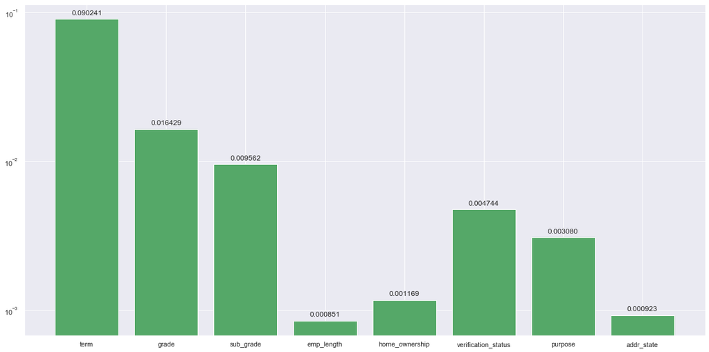

```python
### Correlation

categorical_correlation =  {}

for i in categorical_df.columns:
    categorical_correlation[i] = theils_u(categorical_df[i].values, target_df.values)

plt.rcParams['figure.figsize'] = [20, 10]

fig, ax = plt.subplots()
rects1 = ax.bar(categorical_correlation.keys(), categorical_correlation.values(), log=True, color='g')

def autolabel(rects):
    """
    Attach a text label above each bar displaying its height
    """
    for rect in rects:
        height = rect.get_height()
        ax.text(rect.get_x() + rect.get_width()/2., 1.05*height,
                '%f' % float(height),
        ha='center', va='bottom')

autolabel(rects1)

# plt.set_yscale('log')
plt.show()
```

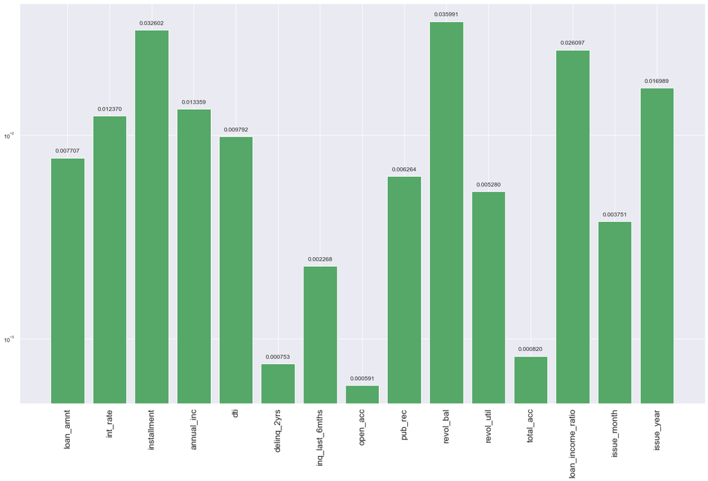

```python
### Correlation

continuous_correlation =  {}

for i in continuous_df.columns:
    continuous_correlation[i] = theils_u(continuous_df[i].values, target_df.values)

plt.rcParams['figure.figsize'] = [25, 15]
plt.rcParams['xtick.labelsize'] = 'x-large'

fig, ax = plt.subplots()
rects1 = ax.bar(continuous_correlation.keys(), continuous_correlation.values(), log=True, color='g',)

def autolabel(rects):
    """
    Attach a text label above each bar displaying its height
    """
    for rect in rects:
        height = rect.get_height()
        ax.text(rect.get_x() + rect.get_width()/2., 1.05*height,
                '%f' % float(height),
        ha='center', va='bottom')

autolabel(rects1)
plt.xticks(rotation=90)

# plt.set_yscale('log')
plt.show()
```

**Looking at Above Correlations, let us expand those correlated categorical and continuous attributes in Univariate and Bivariate Analysis and also eliminating few attributes (eg. revol_bal, revol_util) using domain knowledge**

# Data Analysis - Univariate Analysis

## Continuous Variables

In case of continuous variables, we need to understand the central tendency and spread of the variable.These are measured using various statistical metrics visualization methods such as Boxplot,Histogram/Distribution Plot, Violin Plot etc.

## Categorical Variables

For categorical variables, we’ll use frequency table to understand distribution of each category. It can be be measured using two metrics, Count and Count% against each category. Countplot or Bar chart can be used as visualization.

```python
def univariate(df,col,vartype,hue =None):

    '''
    Univariate function will plot the graphs based on the parameters.
    df      : dataframe name
    col     : Column name
    vartype : variable type : continuos or categorical
                Continuos(0)   : Distribution, Violin & Boxplot will be plotted.
                Categorical(1) : Countplot will be plotted.
    hue     : It's only applicable for categorical analysis.

    '''
    sns.set(style="darkgrid")

    if vartype == 0:
        fig, ax=plt.subplots(nrows =1,ncols=3,figsize=(20,8))
        ax[0].set_title("Distribution Plot")
        sns.distplot(df[col],ax=ax[0])
        ax[1].set_title("Violin Plot")
        sns.violinplot(data =df, x=col,ax=ax[1], inner="quartile")
        ax[2].set_title("Box Plot")
        sns.boxplot(data =df, x=col,ax=ax[2],orient='v')

    if vartype == 1:
        temp = pd.Series(data = hue)
        fig, ax = plt.subplots()
        width = len(df[col].unique()) + 6 + 4*len(temp.unique())
        fig.set_size_inches(width , 7)
        ax = sns.countplot(data = df, x= col, order=df[col].value_counts().index,hue = hue)
        if len(temp.unique()) > 0:
            for p in ax.patches:
                ax.annotate('{:1.1f}%'.format((p.get_height()*100)/float(len(df))), (p.get_x()+0.05, p.get_height()+20))
        else:
            for p in ax.patches:
                ax.annotate(p.get_height(), (p.get_x()+0.32, p.get_height()+20))
        del temp
    else:
        exit

    plt.show()
```

### Loan Amount

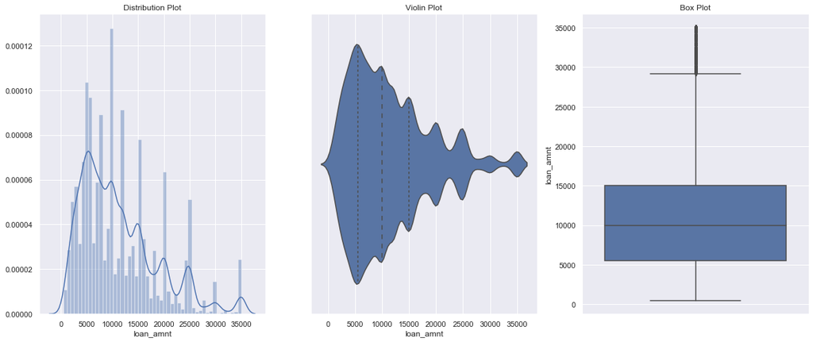

```python
univariate(df=df,col='loan_amnt',vartype=0)
```

**Insights: Most of the loan amounts are distributed between 5000 to 15000**

### Interest Rate

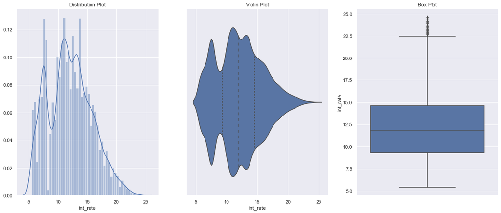

```python
univariate(df=df,col='int_rate',vartype=0)
```

**Insights: Most of the interest rate are distributed between 8.5% to 15%**

### Annual Income

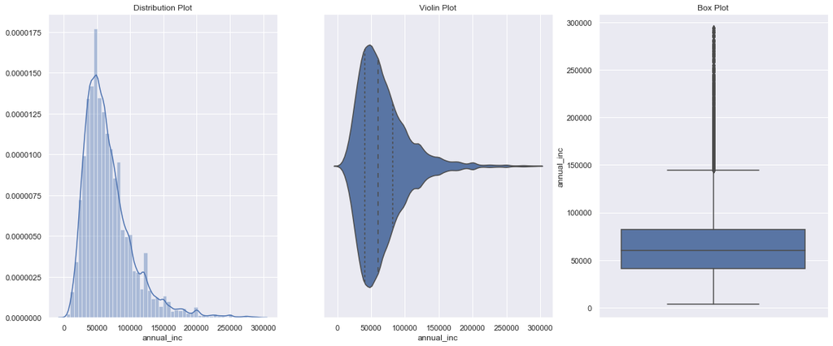

```python
univariate(df=df,col='annual_inc',vartype=0)
```

### Loan Status

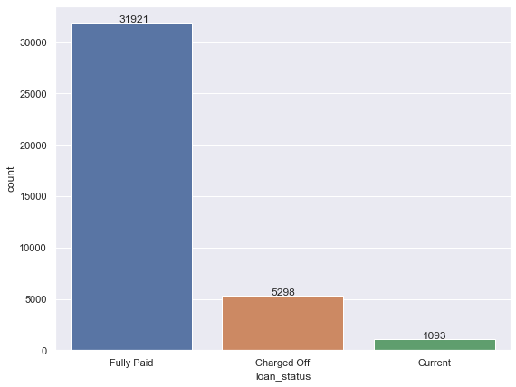

```python
univariate(df=df,col='loan_status',vartype=1)
```

**Insights: 14% of the applicants Charged off.**

### Purpose of Loan

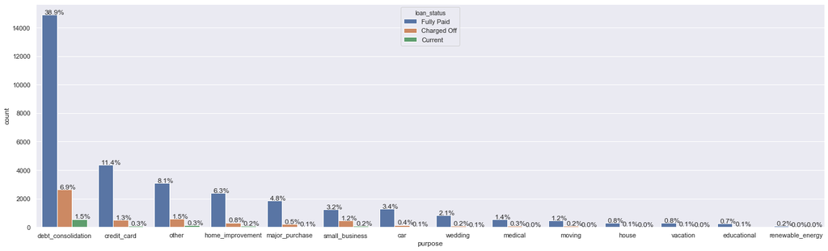

```python
univariate(df=df,col='purpose',vartype=1,hue='loan_status')
```

### Home Ownership wise Loan

```python
df.home_ownership.unique()
```

```
array(['RENT', 'OWN', 'MORTGAGE', 'OTHER', 'NONE'], dtype=object)
```

```python
# Remove rows where home_ownership'=='OTHER', 'NONE', 'ANY'
rem = ['OTHER', 'NONE', 'ANY']
df.drop(df[df['home_ownership'].isin(rem)].index,inplace=True)
df.home_ownership.unique()
```

```
array(['RENT', 'OWN', 'MORTGAGE'], dtype=object)
```

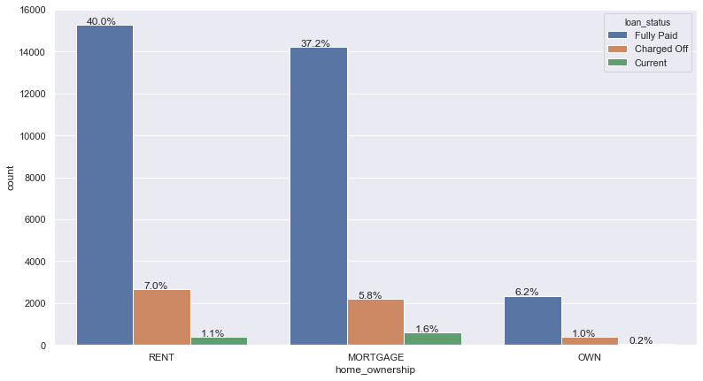

```python
univariate(df=df,col='home_ownership',vartype=1,hue='loan_status')
```

**Insights: 48% of applicants are living in rented home whereas 44% applicants were mortagaged their home.**

### Year wise Loan

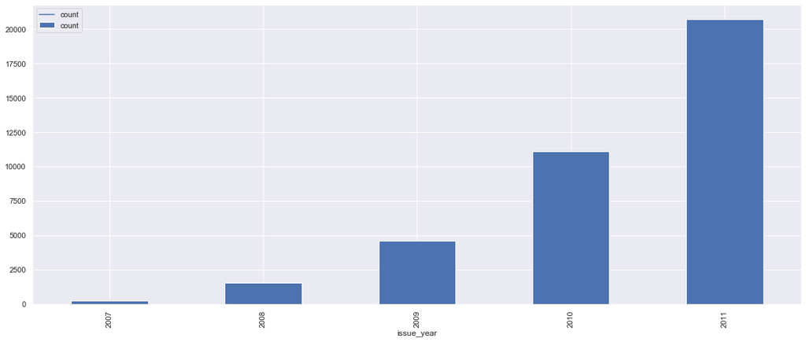

```python
year_wise =df.groupby(by= [df.issue_year])[['loan_status']].count()
year_wise.rename(columns={"loan_status": "count"},inplace=True)
ax =year_wise.plot(figsize=(20,8))
year_wise.plot(kind='bar',figsize=(20,8),ax = ax)
plt.show()
```

### Loan Term

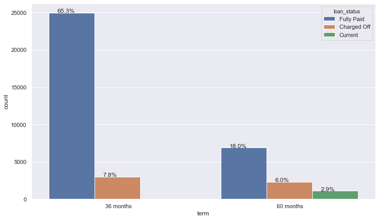

```python
univariate(df=df,col='term',vartype=1,hue='loan_status')
```

**Insights: 73% of applicants applied loan for 36 months term period.**

# Bivariate/Multivariate Analysis with Probability of Charge off

### Categorical Variables vs Probability of Charged Off

The main motive of this use case to find what parameters are impacting the most on Loan Status that is if a applicant will successfully complete the loan term or will charge off.

So we will be using a new term now Probability of Charged Off that will be equal to :

[figure not shown]

We will calculate this probability w.r.t each column in bivariate analysis & will see how the Probability of Charged Off changes with these columns.

We will create a user defined function for this.

```python
'''
'crosstab' function will be used to get the summarized table for each column(passed as a variable) along
with probability of charge off w.r.t that column.
'''

def crosstab(df,col):
    '''
    df : Dataframe
    col: Column Name
    '''
    crosstab = pd.crosstab(df[col], df['loan_status'],margins=True)
    crosstab['Probability_Charged Off'] = round((crosstab['Charged Off']/crosstab['All']),3)
    crosstab = crosstab[0:-1]
    return crosstab


'''
'bivariate_prob' function will be used to plot count of values for each column(passed as a variable)
stacked across 'loan_status' along with probability of charged off as a line chart.
'''

# Probability of charge off
def bivariate_prob(df,col,stacked= True):
    '''
    df      : Dataframe
    col     : Column Name
    stacked : True(default) for Stacked Bar
    '''
    # get dataframe from crosstab function
    plotCrosstab = crosstab(df,col)

    linePlot = plotCrosstab[['Probability_Charged Off']]
    barPlot =  plotCrosstab.iloc[:,0:2]
    ax = linePlot.plot(figsize=(20,8), marker='o',color = 'b')
    ax2 = barPlot.plot(kind='bar',ax = ax,rot=1,secondary_y=True,stacked=stacked)
    ax.set_title(df[col].name.title()+' vs Probability Charge Off',fontsize=20,weight="bold")
    ax.set_xlabel(df[col].name.title(),fontsize=14)
    ax.set_ylabel('Probability of Charged off',color = 'b',fontsize=14)
    ax2.set_ylabel('Number of Applicants',color = 'g',fontsize=14)
    plt.show()
```

### Location vs Probability Charge Off

| loan_status addr_state | Charged Off | Current | Fully Paid | All | Probability_Charged Off |
| --- | --- | --- | --- | --- | --- |
| NJ | 272 | 56 | 1470 | 1798 | 0.1510 |
| NM | 29 | 3 | 148 | 180 | 0.1610 |
| NV | 100 | 17 | 359 | 476 | 0.2100 |
| NY | 465 | 109 | 3095 | 3669 | 0.1270 |
| OH | 140 | 44 | 996 | 1180 | 0.1190 |
| OK | 40 | 11 | 242 | 293 | 0.1370 |
| OR | 68 | 16 | 351 | 435 | 0.1560 |
| PA | 166 | 46 | 1261 | 1473 | 0.1130 |
| RI | 25 | 4 | 164 | 193 | 0.1300 |
| SC | 64 | 13 | 384 | 461 | 0.1390 |
| SD | 11 | 2 | 49 | 62 | 0.1770 |
| TN | 2 | 0 | 15 | 17 | 0.1180 |
| TX | 296 | 67 | 2274 | 2637 | 0.1120 |
| UT | 39 | 5 | 207 | 251 | 0.1550 |
| VA | 168 | 38 | 1154 | 1360 | 0.1240 |
| VT | 6 | 1 | 45 | 52 | 0.1150 |
| WA | 118 | 22 | 663 | 803 | 0.1470 |
| WI | 58 | 20 | 365 | 443 | 0.1310 |
| WV | 20 | 4 | 143 | 167 | 0.1200 |
| WY | 3 | 3 | 73 | 79 | 0.0380 |

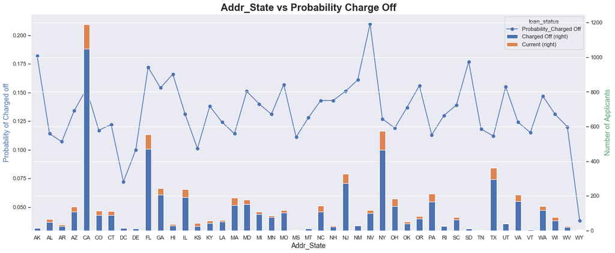

```python
filter_states = df.addr_state.value_counts()
filter_states = filter_states[(filter_states < 10)]

loan_filter_states = df.drop(labels = df[df.addr_state.isin(filter_states.index)].index)

states = crosstab(loan_filter_states,'addr_state')
display(states.tail(20))

bivariate_prob(df =loan_filter_states,col ='addr_state')
```

**Insights: There are multiple States/Provinces with high probability of charge,highest being 'NV' at 21%**

### Purpose of Loan vs Probability Charge Off

| loan_status purpose | Charged Off | Current | Fully Paid | All | Probability_Charged Off |
| --- | --- | --- | --- | --- | --- |
| car | 153 | 49 | 1289 | 1491 | 0.1030 |
| credit_card | 504 | 101 | 4360 | 4965 | 0.1020 |
| debt_consolidation | 2633 | 566 | 14884 | 18083 | 0.1460 |
| educational | 50 | 0 | 258 | 308 | 0.1620 |
| home_improvement | 318 | 92 | 2405 | 2815 | 0.1130 |
| house | 57 | 14 | 288 | 359 | 0.1590 |
| major_purchase | 203 | 35 | 1850 | 2088 | 0.0970 |
| medical | 100 | 12 | 547 | 659 | 0.1520 |
| moving | 82 | 7 | 462 | 551 | 0.1490 |
| other | 580 | 119 | 3082 | 3781 | 0.1530 |
| renewable_energy | 17 | 1 | 74 | 92 | 0.1850 |
| small_business | 448 | 73 | 1231 | 1752 | 0.2560 |
| vacation | 50 | 4 | 297 | 351 | 0.1420 |
| wedding | 85 | 20 | 814 | 919 | 0.0920 |

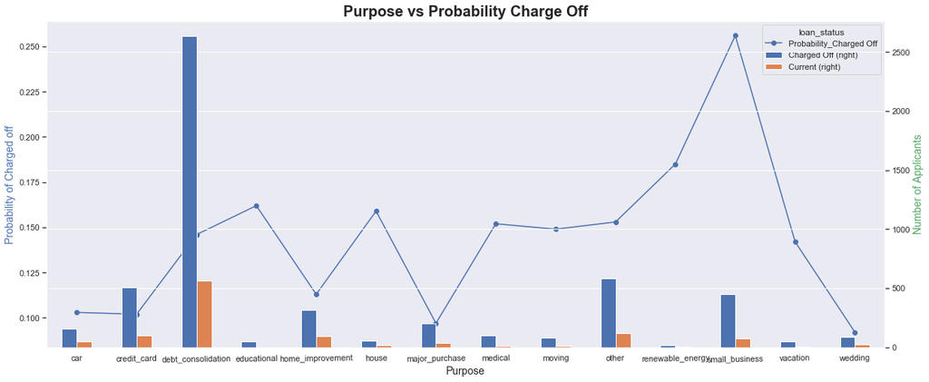

```python
purpose = crosstab(df,'purpose')
display(purpose)

bivariate_prob(df =df,col ='purpose',stacked=False)
```

**Insights: Applicants who has taken the Loan for 'small business' has the highest probabilty of charge off of 25.6%. So bank should take extra caution like take some asset or guarentee while approving the loan for purpose of 'small business'**

### Grade/Subgrade vs Probability Charge Off

| loan_status grade | Charged Off | Current | Fully Paid | All | Probability_Charged Off |
| --- | --- | --- | --- | --- | --- |
| A | 550 | 35 | 9044 | 9629 | 0.0570 |
| B | 1330 | 327 | 9930 | 11587 | 0.1150 |
| C | 1256 | 255 | 6315 | 7826 | 0.1600 |
| D | 1062 | 214 | 3844 | 5120 | 0.2070 |
| E | 682 | 174 | 1882 | 2738 | 0.2490 |
| F | 306 | 71 | 635 | 1012 | 0.3020 |
| G | 94 | 17 | 191 | 302 | 0.3110 |

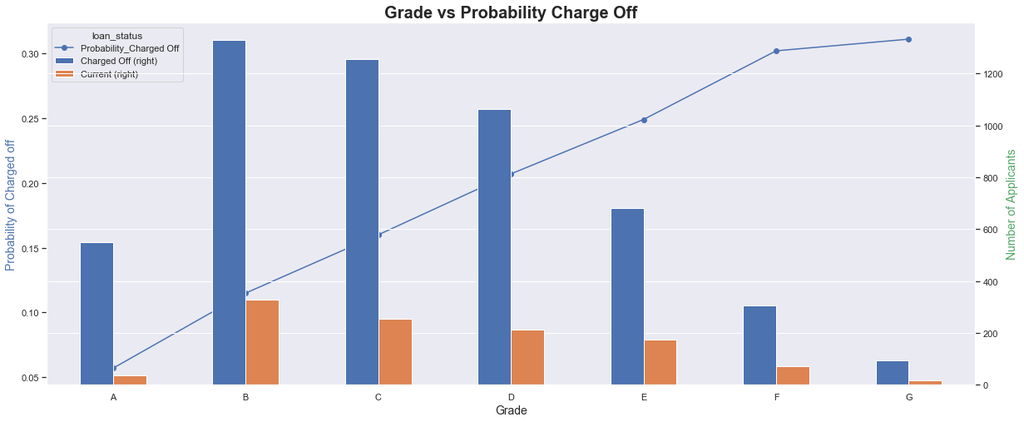

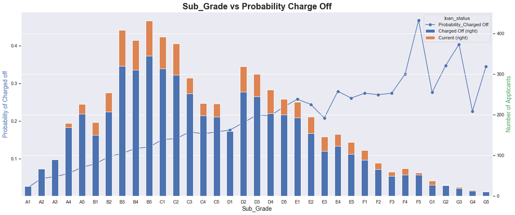

```python
grade = crosstab(df,'grade')
display(grade)

bivariate_prob(df =df,col ='grade',stacked=False)
bivariate_prob(df =df,col ='sub_grade')
```

**Insights: As we move from Grade A to G, probability that person will charged off is increasing.**

### Annual Income Range vs Probability Charge Off

| loan_status annual_inc_range | Charged Off | Current | Fully Paid | All | Probability_Charged Off |
| --- | --- | --- | --- | --- | --- |
| 0-25000 | 399 | 16 | 1839 | 2254 | 0.1770 |
| 25000-50000 | 1983 | 312 | 10344 | 12639 | 0.1570 |
| 50000-75000 | 1622 | 348 | 9786 | 11756 | 0.1380 |
| 75000-100000 | 712 | 218 | 5233 | 6163 | 0.1160 |
| 100000 and above | 564 | 199 | 4639 | 5402 | 0.1040 |

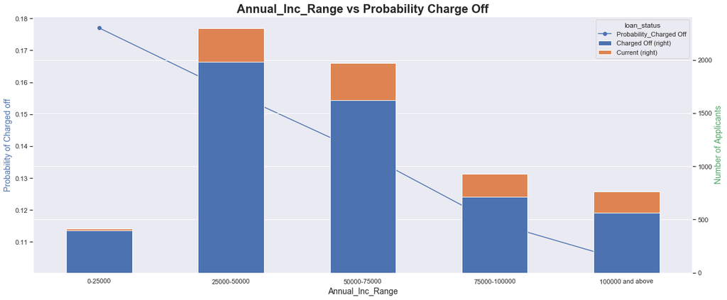

```python
annual_inc_range = crosstab(df,'annual_inc_range')
display(annual_inc_range)

bivariate_prob(df =df,col ='annual_inc_range')
```

**Insights: As the annual income is decreasing the probability that person will default is increasing with highest of 17% at (0 to 25000) salary bracket.**

### Interest rate Range vs Probability Charge Off

| loan_status int_rate_range | Charged Off | Current | Fully Paid | All | Probability_Charged Off |
| --- | --- | --- | --- | --- | --- |
| 0-7.5 | 230 | 6 | 4862 | 5098 | 0.0450 |
| 7.5-10 | 522 | 64 | 6138 | 6724 | 0.0780 |
| 10-12.5 | 1158 | 254 | 7915 | 9327 | 0.1240 |
| 12.5-15 | 1383 | 250 | 7220 | 8853 | 0.1560 |
| 15 and above | 1704 | 419 | 5251 | 7374 | 0.2310 |

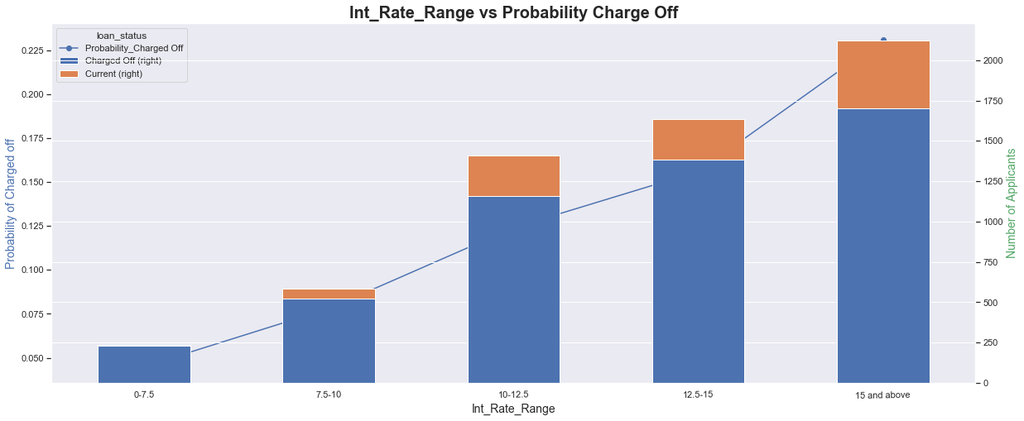

```python
int_rate_range = crosstab(df,'int_rate_range')
display(int_rate_range)

bivariate_prob(df =df,col ='int_rate_range')
```

**Insights: As the interest rate is increasing the probability that person will default is increasing with highest of 23% at 15% & above bracket.**

### Employment Length vs Probability Charge Off

| loan_status emp_length | Charged Off | Current | Fully Paid | All | Probability_Charged Off |
| --- | --- | --- | --- | --- | --- |
| 1 year | 439 | 71 | 2682 | 3192 | 0.1380 |
| 10+ years | 1307 | 389 | 7071 | 8767 | 0.1490 |
| 2 years | 556 | 97 | 3696 | 4349 | 0.1280 |
| 3 years | 543 | 83 | 3426 | 4052 | 0.1340 |
| 4 years | 449 | 94 | 2862 | 3405 | 0.1320 |
| 5 years | 445 | 87 | 2713 | 3245 | 0.1370 |
| 6 years | 302 | 61 | 1850 | 2213 | 0.1360 |
| 7 years | 260 | 62 | 1437 | 1759 | 0.1480 |
| 8 years | 199 | 43 | 1217 | 1459 | 0.1360 |
| 9 years | 155 | 32 | 1061 | 1248 | 0.1240 |
| < 1 year | 625 | 74 | 3826 | 4525 | 0.1380 |

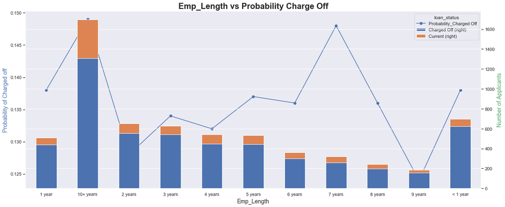

```python
emp_length = crosstab(df,'emp_length')
display(emp_length)

bivariate_prob(df =df,col ='emp_length')
```

# Conclusion